# Introduction to Wrangling and Visualization Part II

# Introduction to dplyr

Our goal is to get data into R in a format that is most useful for completing the data science tasks we ultimately want to carry out in order to answer the questions we are most concerned with. In many cases we may not even know what questions we can answer with our data until we have explored the characteristics of the data and data wrangling might even be a significant component of data exploration.

Some common data wrangling tasks include:

1. Dealing with missing values
2. Arranging values in a column or columns in some way
3. Adding additional columns
4. Removing columns or rows
5. Aggregating parts of the data by a class or classes
6. Spreading data in a column across multiple rows
7. Combining information that is spread across multiple datasets

The dplyr package in the tidyverse family of packages (which includes ggplot2 that we have already worked with) contains functions that facilitate data wrangling. The most important functions to know about are:

- filter() - subsets data by rows
- select() - subsets data by columns
- arrange() - sorts the data by row
- mutate() - add or modifies columns in data
- summarise() - aggregates data across rows

In the next section, we will look at each of these functions in turn.

# A Running Example

In May 2015, [fivethirtyeight](https://fivethirtyeight.com/) published an article [Joining The Avengers Is As Deadly As Jumping Off A Four-Story Building](https://fivethirtyeight.com/features/avengers-death-comics-age-of-ultron/) that seeks to examine the mortality rate of Marvel comic characters. They have made their dataset publicly available and we will use it to illustrate some data wrangling techniques.

Let’s load our most important libraries and then read in the data which can be found [here](https://github.com/fivethirtyeight/data/tree/master/avengers).

```r
library(dplyr)
library(ggplot2)
```

```r
avengers_df <- read.csv("https://raw.githubusercontent.com/fivethirtyeight/data/master/avengers/avengers.csv")
```

Just to see what is going on in the data, let’s determine the size of the data andexamine first few and last few rows:

```r
dim(avengers_df)
```

```
[1] 173  21
```

```r
head(avengers_df)
```

|  | URL | Name.Alias | Appearances | Current. | Gender | Probationary.Introl | Full.Reserve.Avengers.Intro | Year | Years.since.joining | Honorary | Death1 | Return1 | Death2 | Return2 | Death3 | Return3 | Death4 | Return4 | Death5 | Return5 | Notes |
| --- | --- | --- | --- | --- | --- | --- | --- | --- | --- | --- | --- | --- | --- | --- | --- | --- | --- | --- | --- | --- | --- |
| 1 | http://marvel.wikia.com/Henry_Pym_(Earth-616) | Henry Jonathan "Hank" Pym | 1269 | YES | MALE |  | Sep-63 | 1963 | 52 | Full | YES | NO |  |  |  |  |  |  |  |  | Merged with Ultron in Rage of Ultron Vol. 1. A funeral was held. |
| 2 | http://marvel.wikia.com/Janet_van_Dyne_(Earth-616) | Janet van Dyne | 1165 | YES | FEMALE |  | Sep-63 | 1963 | 52 | Full | YES | YES |  |  |  |  |  |  |  |  | Dies in Secret Invasion V1:I8. Actually was sent tto Microverse later recovered |
| 3 | http://marvel.wikia.com/Anthony_Stark_(Earth-616) | Anthony Edward "Tony" Stark | 3068 | YES | MALE |  | Sep-63 | 1963 | 52 | Full | YES | YES |  |  |  |  |  |  |  |  | Death: "Later while under the influence of Immortus Stark committed a number of horrible acts and was killed.' This set up young Tony. Franklin Richards later brought him back |
| 4 | http://marvel.wikia.com/Robert_Bruce_Banner_(Earth-616) | Robert Bruce Banner | 2089 | YES | MALE |  | Sep-63 | 1963 | 52 | Full | YES | YES |  |  |  |  |  |  |  |  | Dies in Ghosts of the Future arc. However "he had actually used a hidden Pantheon base to survive" |
| 5 | http://marvel.wikia.com/Thor_Odinson_(Earth-616) | Thor Odinson | 2402 | YES | MALE |  | Sep-63 | 1963 | 52 | Full | YES | YES | YES | NO |  |  |  |  |  |  | Dies in Fear Itself brought back because that's kind of the whole point. Second death in Time Runs Out has not yet returned |
| 6 | http://marvel.wikia.com/Richard_Jones_(Earth-616) | Richard Milhouse Jones | 612 | YES | MALE |  | Sep-63 | 1963 | 52 | Honorary | NO |  |  |  |  |  |  |  |  |  | NA |

```r
tail(avengers_df)
```

|  | URL | Name.Alias | Appearances | Current. | Gender | Probationary.Introl | Full.Reserve.Avengers.Intro | Year | Years.since.joining | Honorary | Death1 | Return1 | Death2 | Return2 | Death3 | Return3 | Death4 | Return4 | Death5 | Return5 | Notes |
| --- | --- | --- | --- | --- | --- | --- | --- | --- | --- | --- | --- | --- | --- | --- | --- | --- | --- | --- | --- | --- | --- |
| 168 | http://marvel.wikia.com/Alexis_(Earth-616)# | Alexis | 13 | YES | FEMALE |  | 13-Nov | 2013 | 2 | Full | NO |  |  |  |  |  |  |  |  |  | NA |
| 169 | http://marvel.wikia.com/Eric_Brooks_(Earth-616)# | Eric Brooks | 198 | YES | MALE |  | 13-Nov | 2013 | 2 | Full | NO |  |  |  |  |  |  |  |  |  | NA |
| 170 | http://marvel.wikia.com/Adam_Brashear_(Earth-616)# | Adam Brashear | 29 | YES | MALE |  | 14-Jan | 2014 | 1 | Full | NO |  |  |  |  |  |  |  |  |  | NA |
| 171 | http://marvel.wikia.com/Victor_Alvarez_(Earth-616)# | Victor Alvarez | 45 | YES | MALE |  | 14-Jan | 2014 | 1 | Full | NO |  |  |  |  |  |  |  |  |  | NA |
| 172 | http://marvel.wikia.com/Ava_Ayala_(Earth-616)# | Ava Ayala | 49 | YES | FEMALE |  | 14-Jan | 2014 | 1 | Full | NO |  |  |  |  |  |  |  |  |  | NA |
| 173 | http://marvel.wikia.com/Kaluu_(Earth-616)# | Kaluu | 35 | YES | MALE |  | 15-Jan | 2015 | 0 | Full | NO |  |  |  |  |  |  |  |  |  | NA |

It may also be useful to get a quick idea about the summary stats of the variables in the data:

```r
summary(avengers_df)
```

```
                                                         URL                    Name.Alias   Appearances
 http://marvel.wikia.com/2ZP45-9-X-51_(Earth-616)#         :  1                      : 10   Min.   :   2.0
 http://marvel.wikia.com/Abyss_(Ex_Nihilo%27s)_(Earth-616)#:  1   Vance Astrovik     :  2   1st Qu.:  58.0
 http://marvel.wikia.com/Adam_Brashear_(Earth-616)#        :  1   "Giulietta Nefaria":  1   Median : 132.0
 http://marvel.wikia.com/Alani_Ryan_(Earth-616)#           :  1   Adam               :  1   Mean   : 414.1
 http://marvel.wikia.com/Alexander_Summers_(Earth-616)#    :  1   Adam Brashear      :  1   3rd Qu.: 491.0
 http://marvel.wikia.com/Alexis_(Earth-616)#               :  1   Alani Ryan         :  1   Max.   :4333.0
 (Other)                                                   :167   (Other)            :157
 Current.    Gender    Probationary.Introl Full.Reserve.Avengers.Intro      Year      Years.since.joining
 NO :91   FEMALE: 58          :158                : 14                 Min.   :1900   Min.   :  0.00
 YES:82   MALE  :115   Apr-77 :  2         10-Aug :  6                 1st Qu.:1979   1st Qu.:  5.00
                       Feb-91 :  2         10-May :  6                 Median :1996   Median : 19.00
                       Jul-75 :  2         13-Feb :  6                 Mean   :1988   Mean   : 26.55
                       Aug-91 :  1         Feb-78 :  6                 3rd Qu.:2010   3rd Qu.: 36.00
                       Jan-83 :  1         Sep-63 :  6                 Max.   :2015   Max.   :115.00
                       (Other):  7         (Other):129
         Honorary   Death1    Return1   Death2    Return2   Death3    Return3   Death4    Return4   Death5
 Academy     : 17   NO :104      :104      :156      :157      :171      :171      :172      :172      :172
 Full        :138   YES: 69   NO : 23   NO :  1   NO :  8   YES:  2   NO :  1   YES:  1   YES:  1   YES:  1
 Honorary    : 16             YES: 46   YES: 16   YES:  8             YES:  1
 Probationary:  2



 Return5
    :172
 YES:  1





                                                                                                                                                                               Notes
 Died in New_Avengers_Vol_3_32                                                                                                                                                    : 4
 Died in Murderworld during Avengers Arena                                                                                                                                        : 2
  Reduced her to a pile of bones and organsby Vargas. Brought back by Chaos King. Died second time in Chaos_War:_Dead_Avengers_Vol_1_3                                            : 1
 Accidently killed by Zaran                                                                                                                                                       : 1
 Became posessed died to purge self of corruption. Revived as undead Avenger minion of the Grim Reaper. Returned to the spirit world by the Scarlet Witch. Has since stayed dead. : 1
 (Other)                                                                                                                                                                          :66
 NA's                                                                                                                                                                             :98
```

**Question:** What do you observe about the data so far?

```r
data_url <- "https://raw.githubusercontent.com/fivethirtyeight/data/master/avengers/avengers.csv"
avengers_df <- read.csv(data_url,na.strings = "")
```

Now look at the first few rowsn adn summary stats again:

```r
head(avengers_df)
```

|  | URL | Name.Alias | Appearances | Current. | Gender | Probationary.Introl | Full.Reserve.Avengers.Intro | Year | Years.since.joining | Honorary | Death1 | Return1 | Death2 | Return2 | Death3 | Return3 | Death4 | Return4 | Death5 | Return5 | Notes |
| --- | --- | --- | --- | --- | --- | --- | --- | --- | --- | --- | --- | --- | --- | --- | --- | --- | --- | --- | --- | --- | --- |
| 1 | http://marvel.wikia.com/Henry_Pym_(Earth-616) | Henry Jonathan "Hank" Pym | 1269 | YES | MALE | NA | Sep-63 | 1963 | 52 | Full | YES | NO | NA | NA | NA | NA | NA | NA | NA | NA | Merged with Ultron in Rage of Ultron Vol. 1. A funeral was held. |
| 2 | http://marvel.wikia.com/Janet_van_Dyne_(Earth-616) | Janet van Dyne | 1165 | YES | FEMALE | NA | Sep-63 | 1963 | 52 | Full | YES | YES | NA | NA | NA | NA | NA | NA | NA | NA | Dies in Secret Invasion V1:I8. Actually was sent tto Microverse later recovered |
| 3 | http://marvel.wikia.com/Anthony_Stark_(Earth-616) | Anthony Edward "Tony" Stark | 3068 | YES | MALE | NA | Sep-63 | 1963 | 52 | Full | YES | YES | NA | NA | NA | NA | NA | NA | NA | NA | Death: "Later while under the influence of Immortus Stark committed a number of horrible acts and was killed.' This set up young Tony. Franklin Richards later brought him back |
| 4 | http://marvel.wikia.com/Robert_Bruce_Banner_(Earth-616) | Robert Bruce Banner | 2089 | YES | MALE | NA | Sep-63 | 1963 | 52 | Full | YES | YES | NA | NA | NA | NA | NA | NA | NA | NA | Dies in Ghosts of the Future arc. However "he had actually used a hidden Pantheon base to survive" |
| 5 | http://marvel.wikia.com/Thor_Odinson_(Earth-616) | Thor Odinson | 2402 | YES | MALE | NA | Sep-63 | 1963 | 52 | Full | YES | YES | YES | NO | NA | NA | NA | NA | NA | NA | Dies in Fear Itself brought back because that's kind of the whole point. Second death in Time Runs Out has not yet returned |
| 6 | http://marvel.wikia.com/Richard_Jones_(Earth-616) | Richard Milhouse Jones | 612 | YES | MALE | NA | Sep-63 | 1963 | 52 | Honorary | NO | NA | NA | NA | NA | NA | NA | NA | NA | NA | NA |

```r
summary(avengers_df)
```

```
                                                         URL                    Name.Alias   Appearances
 http://marvel.wikia.com/2ZP45-9-X-51_(Earth-616)#         :  1   Vance Astrovik     :  2   Min.   :   2.0
 http://marvel.wikia.com/Abyss_(Ex_Nihilo%27s)_(Earth-616)#:  1   "Giulietta Nefaria":  1   1st Qu.:  58.0
 http://marvel.wikia.com/Adam_Brashear_(Earth-616)#        :  1   Adam               :  1   Median : 132.0
 http://marvel.wikia.com/Alani_Ryan_(Earth-616)#           :  1   Adam Brashear      :  1   Mean   : 414.1
 http://marvel.wikia.com/Alexander_Summers_(Earth-616)#    :  1   Alani Ryan         :  1   3rd Qu.: 491.0
 http://marvel.wikia.com/Alexis_(Earth-616)#               :  1   (Other)            :157   Max.   :4333.0
 (Other)                                                   :167   NA's               : 10
 Current.    Gender    Probationary.Introl Full.Reserve.Avengers.Intro      Year      Years.since.joining
 NO :91   FEMALE: 58   Apr-77 :  2         10-Aug :  6                 Min.   :1900   Min.   :  0.00
 YES:82   MALE  :115   Feb-91 :  2         10-May :  6                 1st Qu.:1979   1st Qu.:  5.00
                       Jul-75 :  2         13-Feb :  6                 Median :1996   Median : 19.00
                       Aug-91 :  1         Feb-78 :  6                 Mean   :1988   Mean   : 26.55
                       Jan-83 :  1         Sep-63 :  6                 3rd Qu.:2010   3rd Qu.: 36.00
                       (Other):  7         (Other):129                 Max.   :2015   Max.   :115.00
                       NA's   :158         NA's   : 14
         Honorary   Death1    Return1     Death2    Return2     Death3    Return3     Death4    Return4
 Academy     : 17   NO :104   NO  : 23   NO  :  1   NO  :  8   YES :  2   NO  :  1   YES :  1   YES :  1
 Full        :138   YES: 69   YES : 46   YES : 16   YES :  8   NA's:171   YES :  1   NA's:172   NA's:172
 Honorary    : 16             NA's:104   NA's:156   NA's:157              NA's:171
 Probationary:  2



  Death5    Return5
 YES :  1   YES :  1
 NA's:172   NA's:172





                                                                                                                                                                               Notes
 NA                                                                                                                                                                               :98
 Died in New_Avengers_Vol_3_32                                                                                                                                                    : 4
 Died in Murderworld during Avengers Arena                                                                                                                                        : 2
  Reduced her to a pile of bones and organsby Vargas. Brought back by Chaos King. Died second time in Chaos_War:_Dead_Avengers_Vol_1_3                                            : 1
 Accidently killed by Zaran                                                                                                                                                       : 1
 Became posessed died to purge self of corruption. Revived as undead Avenger minion of the Grim Reaper. Returned to the spirit world by the Scarlet Witch. Has since stayed dead. : 1
 (Other)                                                                                                                                                                          :66
```

## Selecting columns from a data frame

The select function from dplyr allows us to subset data by columns. For example, suppose we only want to work with the name/alias and appearances variables. We can select for these columns with

```r
select(avengers_df,"Name.Alias","Appearances")
```

| Name.Alias | Appearances |
| --- | --- |
| Henry Jonathan "Hank" Pym | 1269 |
| Janet van Dyne | 1165 |
| Anthony Edward "Tony" Stark | 3068 |
| Robert Bruce Banner | 2089 |
| Thor Odinson | 2402 |
| Richard Milhouse Jones | 612 |
| Steven Rogers | 3458 |
| Clinton Francis Barton | 1456 |
| Pietro Maximoff | 769 |
| Wanda Maximoff | 1214 |

[output cut: 163 more lines]

One aspect that is nice about dplyr and it’s functions is that the **pipe** notation can be used. For example,

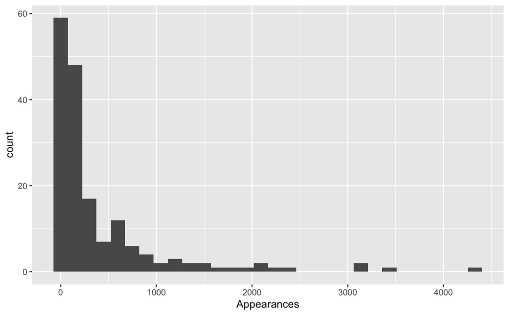

```r
avengers_df %>% select("Name.Alias","Appearances") %>%
  ggplot() +
  geom_histogram(aes(x=Appearances))
```

The pipe basically represents the composition of functions.

You can use a minus sign in select to delete a column. For example,

```r
avengers_df %>% select(-"URL",-"Notes") %>% head()
```

|  | Name.Alias | Appearances | Current. | Gender | Probationary.Introl | Full.Reserve.Avengers.Intro | Year | Years.since.joining | Honorary | Death1 | Return1 | Death2 | Return2 | Death3 | Return3 | Death4 | Return4 | Death5 | Return5 |
| --- | --- | --- | --- | --- | --- | --- | --- | --- | --- | --- | --- | --- | --- | --- | --- | --- | --- | --- | --- |
| 1 | Henry Jonathan "Hank" Pym | 1269 | YES | MALE | NA | Sep-63 | 1963 | 52 | Full | YES | NO | NA | NA | NA | NA | NA | NA | NA | NA |
| 2 | Janet van Dyne | 1165 | YES | FEMALE | NA | Sep-63 | 1963 | 52 | Full | YES | YES | NA | NA | NA | NA | NA | NA | NA | NA |
| 3 | Anthony Edward "Tony" Stark | 3068 | YES | MALE | NA | Sep-63 | 1963 | 52 | Full | YES | YES | NA | NA | NA | NA | NA | NA | NA | NA |
| 4 | Robert Bruce Banner | 2089 | YES | MALE | NA | Sep-63 | 1963 | 52 | Full | YES | YES | NA | NA | NA | NA | NA | NA | NA | NA |
| 5 | Thor Odinson | 2402 | YES | MALE | NA | Sep-63 | 1963 | 52 | Full | YES | YES | YES | NO | NA | NA | NA | NA | NA | NA |
| 6 | Richard Milhouse Jones | 612 | YES | MALE | NA | Sep-63 | 1963 | 52 | Honorary | NO | NA | NA | NA | NA | NA | NA | NA | NA | NA |

Notice that select **does not** modify the original data. If you want to use select to create a new dataset you have to use assignment. For example,

```r
character_time_df <- avengers_df %>% select(c(Name.Alias,Appearances,Years.since.joining))
```

Creates a new data frame that we can use for example in plots, e.g.

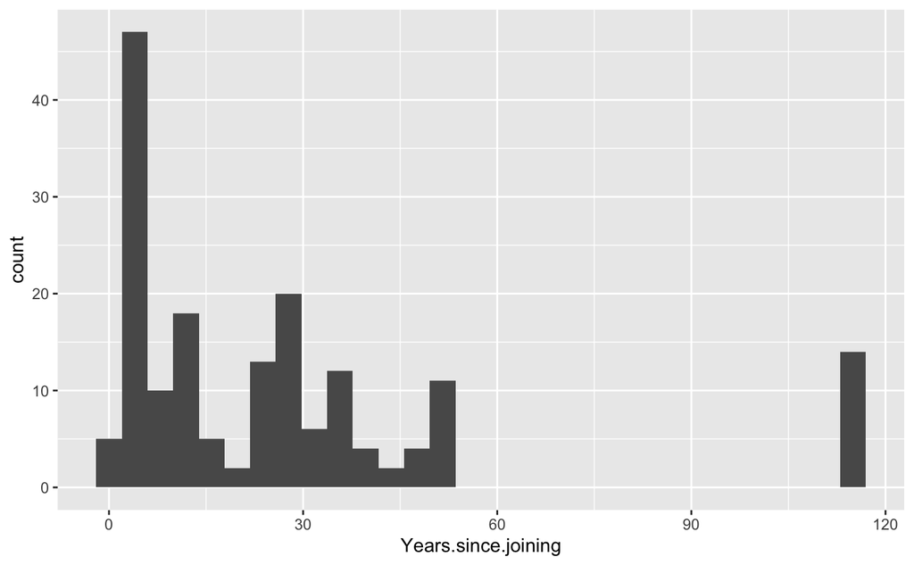

```r
character_time_df %>% ggplot() + geom_histogram(aes(x=Years.since.joining))
```

## Filtering out rows of a data frame

The filter function from dplyr allows us to subset data by rows. Say for example that we only want to see the death characteristics of female characters:

```r
avengers_df %>% filter(Gender=="FEMALE") %>% head()
```

|  | URL | Name.Alias | Appearances | Current. | Gender | Probationary.Introl | Full.Reserve.Avengers.Intro | Year | Years.since.joining | Honorary | Death1 | Return1 | Death2 | Return2 | Death3 | Return3 | Death4 | Return4 | Death5 | Return5 | Notes |
| --- | --- | --- | --- | --- | --- | --- | --- | --- | --- | --- | --- | --- | --- | --- | --- | --- | --- | --- | --- | --- | --- |
| 1 | http://marvel.wikia.com/Janet_van_Dyne_(Earth-616) | Janet van Dyne | 1165 | YES | FEMALE | NA | Sep-63 | 1963 | 52 | Full | YES | YES | NA | NA | NA | NA | NA | NA | NA | NA | Dies in Secret Invasion V1:I8. Actually was sent tto Microverse later recovered |
| 2 | http://marvel.wikia.com/Wanda_Maximoff_(Earth-616) | Wanda Maximoff | 1214 | YES | FEMALE | NA | May-65 | 1965 | 50 | Full | YES | YES | NA | NA | NA | NA | NA | NA | NA | NA | Dies in Uncanny_Avengers_Vol_1_14. Later comes back |
| 3 | http://marvel.wikia.com/Natalia_Romanova_(Earth-616)# | Natalia Alianovna Romanova | 1112 | YES | FEMALE | NA | May-73 | 1973 | 42 | Full | YES | YES | NA | NA | NA | NA | NA | NA | NA | NA | Killed by The Hand. Later revived with The Stone of the Chaste. |
| 4 | http://marvel.wikia.com/Mantis_(Earth-616)# | Brandt | 160 | NO | FEMALE | NA | Aug-73 | 1973 | 42 | Full | YES | YES | NA | NA | NA | NA | NA | NA | NA | NA | Dies in Silver_Surfer_Vol_3_3. Actually "fragments of her essence were spread out all across the universe" |
| 5 | http://marvel.wikia.com/Heather_Douglas_(Earth-616)# | Heather Douglas | 332 | NO | FEMALE | Jul-75 | Sep-76 | 1976 | 39 | Full | YES | YES | YES | YES | NA | NA | NA | NA | NA | NA | Dies in Defenders_Vol_1_152. Later 'Obtained a new body.' Dies in Annihilation:_Conquest_Vol_1_3. Comes back as "As before" also was once named Madame MacEvil because LOL. |
| 6 | http://marvel.wikia.com/Patricia_Walker_(Earth-616)# | Patsy Walker | 557 | NO | FEMALE | Nov-75 | Sep-76 | 1976 | 39 | Full | YES | YES | NA | NA | NA | NA | NA | NA | NA | NA | Died during time on Defenders. Eventually ressurected by villian Grim Reaper along with Mockingbird to fight the Avengers. |

Of course filter and select can be used in conjunction. For example,

```r
avengers_df %>% filter(Gender=="FEMALE") %>% select(-c("URL","Notes")) %>% head()
```

|  | Name.Alias | Appearances | Current. | Gender | Probationary.Introl | Full.Reserve.Avengers.Intro | Year | Years.since.joining | Honorary | Death1 | Return1 | Death2 | Return2 | Death3 | Return3 | Death4 | Return4 | Death5 | Return5 |
| --- | --- | --- | --- | --- | --- | --- | --- | --- | --- | --- | --- | --- | --- | --- | --- | --- | --- | --- | --- |
| 1 | Janet van Dyne | 1165 | YES | FEMALE | NA | Sep-63 | 1963 | 52 | Full | YES | YES | NA | NA | NA | NA | NA | NA | NA | NA |
| 2 | Wanda Maximoff | 1214 | YES | FEMALE | NA | May-65 | 1965 | 50 | Full | YES | YES | NA | NA | NA | NA | NA | NA | NA | NA |
| 3 | Natalia Alianovna Romanova | 1112 | YES | FEMALE | NA | May-73 | 1973 | 42 | Full | YES | YES | NA | NA | NA | NA | NA | NA | NA | NA |
| 4 | Brandt | 160 | NO | FEMALE | NA | Aug-73 | 1973 | 42 | Full | YES | YES | NA | NA | NA | NA | NA | NA | NA | NA |
| 5 | Heather Douglas | 332 | NO | FEMALE | Jul-75 | Sep-76 | 1976 | 39 | Full | YES | YES | YES | YES | NA | NA | NA | NA | NA | NA |
| 6 | Patsy Walker | 557 | NO | FEMALE | Nov-75 | Sep-76 | 1976 | 39 | Full | YES | YES | NA | NA | NA | NA | NA | NA | NA | NA |

You can filter according to any conditional. For example, let’s look at characters that have more than 1000 appearances.

```r
avengers_df %>% filter(Appearances > 1000) %>% select(-c("URL","Notes")) %>% head()
```

|  | Name.Alias | Appearances | Current. | Gender | Probationary.Introl | Full.Reserve.Avengers.Intro | Year | Years.since.joining | Honorary | Death1 | Return1 | Death2 | Return2 | Death3 | Return3 | Death4 | Return4 | Death5 | Return5 |
| --- | --- | --- | --- | --- | --- | --- | --- | --- | --- | --- | --- | --- | --- | --- | --- | --- | --- | --- | --- |
| 1 | Henry Jonathan "Hank" Pym | 1269 | YES | MALE | NA | Sep-63 | 1963 | 52 | Full | YES | NO | NA | NA | NA | NA | NA | NA | NA | NA |
| 2 | Janet van Dyne | 1165 | YES | FEMALE | NA | Sep-63 | 1963 | 52 | Full | YES | YES | NA | NA | NA | NA | NA | NA | NA | NA |
| 3 | Anthony Edward "Tony" Stark | 3068 | YES | MALE | NA | Sep-63 | 1963 | 52 | Full | YES | YES | NA | NA | NA | NA | NA | NA | NA | NA |
| 4 | Robert Bruce Banner | 2089 | YES | MALE | NA | Sep-63 | 1963 | 52 | Full | YES | YES | NA | NA | NA | NA | NA | NA | NA | NA |
| 5 | Thor Odinson | 2402 | YES | MALE | NA | Sep-63 | 1963 | 52 | Full | YES | YES | YES | NO | NA | NA | NA | NA | NA | NA |
| 6 | Steven Rogers | 3458 | YES | MALE | NA | Mar-64 | 1964 | 51 | Full | YES | YES | NA | NA | NA | NA | NA | NA | NA | NA |

**Exercise** Determine how many characters have more than 1000 appearances.

**Exercise** Determine how many characters have died at least once.

**Exercise** Determine how many characters returned after their first death. Is it common or not for characters to return after their first death?

**Exercise** Which character(s) have died the most?

## Arranging rows in a data frame

The dplyr function arrange sorts the data by row.

```r
?arrange
```

**Exercise** Read the documentation on arrange. Use what you learn to apply arrange in order to sort the Marvel characters by their number of appearances.

The default in arrange is to sort in ascending order. If you want to descending this must be specified. For example,

```r
avengers_df %>% arrange(desc(Years.since.joining))
```

| URL | Name.Alias | Appearances | Current. | Gender | Probationary.Introl | Full.Reserve.Avengers.Intro | Year | Years.since.joining | Honorary | Death1 | Return1 | Death2 | Return2 | Death3 | Return3 | Death4 | Return4 | Death5 | Return5 | Notes |
| --- | --- | --- | --- | --- | --- | --- | --- | --- | --- | --- | --- | --- | --- | --- | --- | --- | --- | --- | --- | --- |
| http://marvel.wikia.com/Elvin_Haliday_(Earth-616)# | Elvin Haliday | 158 | NO | MALE | Feb-91 | NA | 1900 | 115 | Probationary | NO | NA | NA | NA | NA | NA | NA | NA | NA | NA | NA |
| http://marvel.wikia.com/William_Baker_(Earth-616)# | William Baker | 355 | NO | MALE | Feb-91 | NA | 1900 | 115 | Probationary | YES | YES | NO | NA | NA | NA | NA | NA | NA | NA | Died in Identity_Disc_Vol_1_1. Later was revealed to be alive and working along with the Vulture. |
| http://marvel.wikia.com/James_Santini_(Earth-616)# | James Santini | 40 | YES | MALE | NA | NA | 1900 | 115 | Academy | NO | NA | NA | NA | NA | NA | NA | NA | NA | NA | NA |
| http://marvel.wikia.com/Emery_Schaub_(Earth-616)# | Emery Schaub | 26 | YES | MALE | NA | NA | 1900 | 115 | Academy | NO | NA | NA | NA | NA | NA | NA | NA | NA | NA | NA |
| http://marvel.wikia.com/Fiona_(Inhuman)_(Earth-616)# | Fiona | 2 | YES | FEMALE | NA | NA | 1900 | 115 | Academy | NO | NA | NA | NA | NA | NA | NA | NA | NA | NA | NA |
| http://marvel.wikia.com/Hollow_(Earth-616)# | Yvette | 22 | YES | FEMALE | NA | NA | 1900 | 115 | Academy | NO | NA | NA | NA | NA | NA | NA | NA | NA | NA | NA |
| http://marvel.wikia.com/Julie_Power_(Earth-616)# | Julie Power | 153 | YES | FEMALE | NA | NA | 1900 | 115 | Academy | NO | NA | NA | NA | NA | NA | NA | NA | NA | NA | NA |
| http://marvel.wikia.com/Alani_Ryan_(Earth-616)# | Alani Ryan | 73 | YES | FEMALE | NA | NA | 1900 | 115 | Academy | NO | NA | NA | NA | NA | NA | NA | NA | NA | NA | NA |
| http://marvel.wikia.com/Johnathon_Gallo_(Earth-616)# | Johnny Gallo | 43 | YES | MALE | NA | NA | 1900 | 115 | Academy | NO | NA | NA | NA | NA | NA | NA | NA | NA | NA | NA |
| http://marvel.wikia.com/Lyra_(Earth-8009)# | Lyra | 55 | YES | FEMALE | NA | NA | 1900 | 115 | Academy | NO | NA | NA | NA | NA | NA | NA | NA | NA | NA | NA |

[output cut: 163 more lines]

**Exercise** Which Marvel characters have had the most appearances?

What happens if we input more than one variable into arrange?

```r
avengers_df %>% arrange(Year,desc(Appearances)) %>% select(Name.Alias,Year,Appearances)
```

| Name.Alias | Year | Appearances |
| --- | --- | --- |
| William Baker | 1900 | 355 |
| Elvin Haliday | 1900 | 158 |
| Julie Power | 1900 | 153 |
| Anya Corazon | 1900 | 108 |
| Michiko Musashi | 1900 | 94 |
| Alani Ryan | 1900 | 73 |
| Kevin Masterson | 1900 | 62 |
| Lyra | 1900 | 55 |
| Johnny Gallo | 1900 | 43 |
| James Santini | 1900 | 40 |

[output cut: 163 more lines]

**Question:** How do you describe the result of the previous output?

We will see later that you can also arrange variables after aggregating by a category.

## Adding a column

The dplyr mutate function allows us to add or modify columns in data. This is very useful if you want to use existing columns in the construction of a new column. For example, lets add a column that contains a 1 in rows where a character has died at least once and a 0 otherwise.

```r
avengers_df %>% select(-c("URL","Notes")) %>% mutate(Death1Count = ifelse(Death1 == "YES",1,0)) %>% head()
```

|  | Name.Alias | Appearances | Current. | Gender | Probationary.Introl | Full.Reserve.Avengers.Intro | Year | Years.since.joining | Honorary | Death1 | Return1 | Death2 | Return2 | Death3 | Return3 | Death4 | Return4 | Death5 | Return5 | Death1Count |
| --- | --- | --- | --- | --- | --- | --- | --- | --- | --- | --- | --- | --- | --- | --- | --- | --- | --- | --- | --- | --- |
| 1 | Henry Jonathan "Hank" Pym | 1269 | YES | MALE | NA | Sep-63 | 1963 | 52 | Full | YES | NO | NA | NA | NA | NA | NA | NA | NA | NA | 1 |
| 2 | Janet van Dyne | 1165 | YES | FEMALE | NA | Sep-63 | 1963 | 52 | Full | YES | YES | NA | NA | NA | NA | NA | NA | NA | NA | 1 |
| 3 | Anthony Edward "Tony" Stark | 3068 | YES | MALE | NA | Sep-63 | 1963 | 52 | Full | YES | YES | NA | NA | NA | NA | NA | NA | NA | NA | 1 |
| 4 | Robert Bruce Banner | 2089 | YES | MALE | NA | Sep-63 | 1963 | 52 | Full | YES | YES | NA | NA | NA | NA | NA | NA | NA | NA | 1 |
| 5 | Thor Odinson | 2402 | YES | MALE | NA | Sep-63 | 1963 | 52 | Full | YES | YES | YES | NO | NA | NA | NA | NA | NA | NA | 1 |
| 6 | Richard Milhouse Jones | 612 | YES | MALE | NA | Sep-63 | 1963 | 52 | Honorary | NO | NA | NA | NA | NA | NA | NA | NA | NA | NA | 0 |

Let’s do the same thing for each possible death, then add one last columns that adds up all the 1’s and assign this to a new data frame:

```r
result_df <- avengers_df %>% select(-c("URL","Notes")) %>% mutate(Death1Count = ifelse(Death1 == "YES",1,0)) %>%
  mutate(Death2Count = ifelse(Death2 == "NO" | is.na(Death2),0,1)) %>%
  mutate(Death3Count = ifelse(Death3 == "NO" | is.na(Death3),0,1)) %>%
  mutate(Death4Count = ifelse(Death4 == "NO" | is.na(Death4),0,1)) %>%
  mutate(Death5Count = ifelse(Death5 == "NO" | is.na(Death5),0,1)) %>%
  mutate(Character_deaths=Death1Count+Death2Count+Death3Count+Death4Count+Death5Count)
```

Let’s examine the result

```r
head(result_df)
```

|  | Name.Alias | Appearances | Current. | Gender | Probationary.Introl | Full.Reserve.Avengers.Intro | Year | Years.since.joining | Honorary | Death1 | Return1 | Death2 | Return2 | Death3 | Return3 | Death4 | Return4 | Death5 | Return5 | Death1Count | Death2Count | Death3Count | Death4Count | Death5Count | Character_deaths |
| --- | --- | --- | --- | --- | --- | --- | --- | --- | --- | --- | --- | --- | --- | --- | --- | --- | --- | --- | --- | --- | --- | --- | --- | --- | --- |
| 1 | Henry Jonathan "Hank" Pym | 1269 | YES | MALE | NA | Sep-63 | 1963 | 52 | Full | YES | NO | NA | NA | NA | NA | NA | NA | NA | NA | 1 | 0 | 0 | 0 | 0 | 1 |
| 2 | Janet van Dyne | 1165 | YES | FEMALE | NA | Sep-63 | 1963 | 52 | Full | YES | YES | NA | NA | NA | NA | NA | NA | NA | NA | 1 | 0 | 0 | 0 | 0 | 1 |
| 3 | Anthony Edward "Tony" Stark | 3068 | YES | MALE | NA | Sep-63 | 1963 | 52 | Full | YES | YES | NA | NA | NA | NA | NA | NA | NA | NA | 1 | 0 | 0 | 0 | 0 | 1 |
| 4 | Robert Bruce Banner | 2089 | YES | MALE | NA | Sep-63 | 1963 | 52 | Full | YES | YES | NA | NA | NA | NA | NA | NA | NA | NA | 1 | 0 | 0 | 0 | 0 | 1 |
| 5 | Thor Odinson | 2402 | YES | MALE | NA | Sep-63 | 1963 | 52 | Full | YES | YES | YES | NO | NA | NA | NA | NA | NA | NA | 1 | 1 | 0 | 0 | 0 | 2 |
| 6 | Richard Milhouse Jones | 612 | YES | MALE | NA | Sep-63 | 1963 | 52 | Honorary | NO | NA | NA | NA | NA | NA | NA | NA | NA | NA | 0 | 0 | 0 | 0 | 0 | 0 |

We can use this now to make a bar plots of the number of deaths.

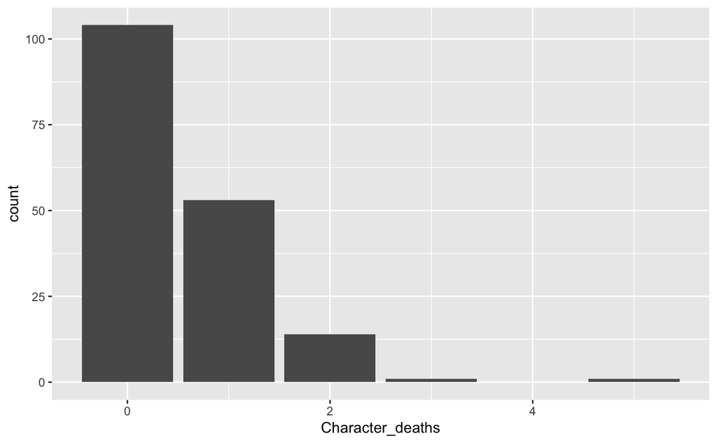

```r
result_df %>% ggplot() + geom_bar(aes(x=Character_deaths))
```

**Question** Do characters tend to die more than once?

## Collapsing a data frame by summaries

The dplyr function summarise will collapse an entire data frame by applying some function to a column(s), typically this is done after aggregating the data across rows using the group_by function.

It is very helpful to read the summarise documentation:

```r
?summarise
```

Here is an initial but very limited example,

```r
avengers_df %>% summarise(median(Appearances))
```

| median(Appearances) |
| --- |
| 132 |

You can apply multiple summary functions. For example,

```r
avengers_df %>% summarise(median(Appearances),mean(Appearances),sd(Appearances))
```

| median(Appearances) | mean(Appearances) | sd(Appearances) |
| --- | --- | --- |
| 132 | 414.052 | 677.992 |

It is better practice to assign names:

```r
avengers_df %>% summarise(median_Appearances=median(Appearances),mean_Appearances=mean(Appearances),sd_Appearances=sd(Appearances))
```

| median_Appearances | mean_Appearances | sd_Appearances |
| --- | --- | --- |
| 132 | 414.052 | 677.992 |

Let’s look at the summary stats for Appearances after aggregating by first death:

```r
avengers_df %>% group_by(Death1) %>% summarise(median_Appearances=median(Appearances),mean_Appearances=mean(Appearances),sd_Appearances=sd(Appearances))
```

| Death1 | median_Appearances | mean_Appearances | sd_Appearances |
| --- | --- | --- | --- |
| NO | 109.5 | 297.4904 | 419.4218 |
| YES | 176.0 | 589.7391 | 918.7732 |

Let’s plot this result for the median:

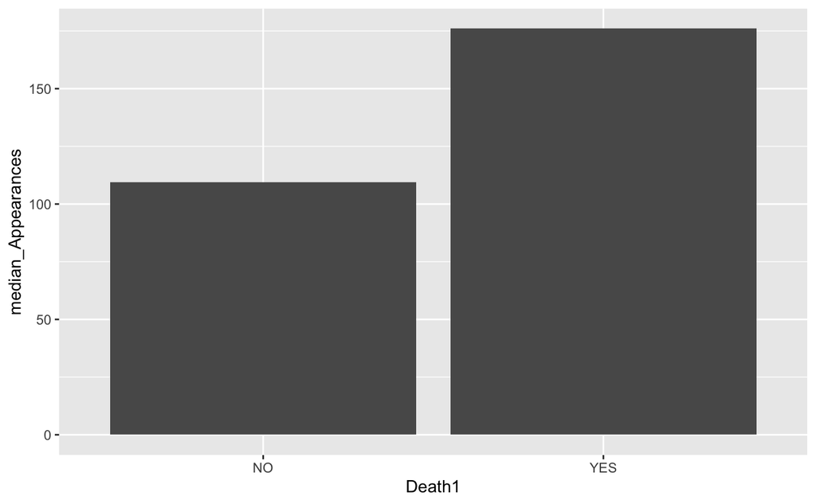

```r
avengers_df %>% group_by(Death1) %>% summarise(median_Appearances=median(Appearances)) %>%
  ggplot() + geom_bar(aes(x=Death1,y=median_Appearances),stat="identity")
```

**Question** Notice that we set the stat to identity, what do you think this does?

**Question** Does it seem strange that of characters dying at least once there is a tendency toward more appearances that those that did not die at least once?

**Exercise** Repeat the grouping and summarising but for max and min number of appearances instead of median, etc.

## A final example

Let’s go back to the familiar gapminder dataset.

```r
library(gapminder)
```

Recall the data:

```r
head(gapminder)
```

| country | continent | year | lifeExp | pop | gdpPercap |
| --- | --- | --- | --- | --- | --- |
| Afghanistan | Asia | 1952 | 28.801 | 8425333 | 779.4453 |
| Afghanistan | Asia | 1957 | 30.332 | 9240934 | 820.8530 |
| Afghanistan | Asia | 1962 | 31.997 | 10267083 | 853.1007 |
| Afghanistan | Asia | 1967 | 34.020 | 11537966 | 836.1971 |
| Afghanistan | Asia | 1972 | 36.088 | 13079460 | 739.9811 |
| Afghanistan | Asia | 1977 | 38.438 | 14880372 | 786.1134 |

What we would like to do examine how life expectancy varies both over time and across the globe. It probably does not make sense to compute only the mean life expectancy (why?). So we will aggregate and then compute the summary.

```r
gapminder %>% group_by(year,continent) %>% summarise(mean_lifeExp=mean(lifeExp))
```

| year | continent | mean_lifeExp |
| --- | --- | --- |
| 1952 | Africa | 39.13550 |
| 1952 | Americas | 53.27984 |
| 1952 | Asia | 46.31439 |
| 1952 | Europe | 64.40850 |
| 1952 | Oceania | 69.25500 |
| 1957 | Africa | 41.26635 |
| 1957 | Americas | 55.96028 |
| 1957 | Asia | 49.31854 |
| 1957 | Europe | 66.70307 |
| 1957 | Oceania | 70.29500 |

[output cut: 50 more lines]

Now we can easily plot this:

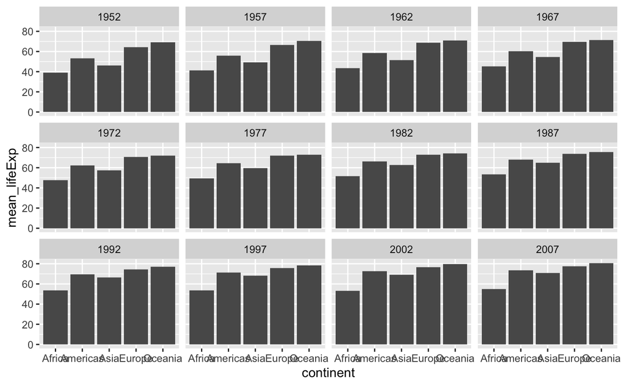

```r
gapminder %>% group_by(year,continent) %>% summarise(mean_lifeExp=mean(lifeExp)) %>%
  ggplot() + geom_bar(aes(x=continent,y=mean_lifeExp),stat="identity") +
  facet_wrap(~year)
```

Notice that the labels on the x-axis are hard to read. There are two easy fixes for this. One is the flip the coordinate axes:

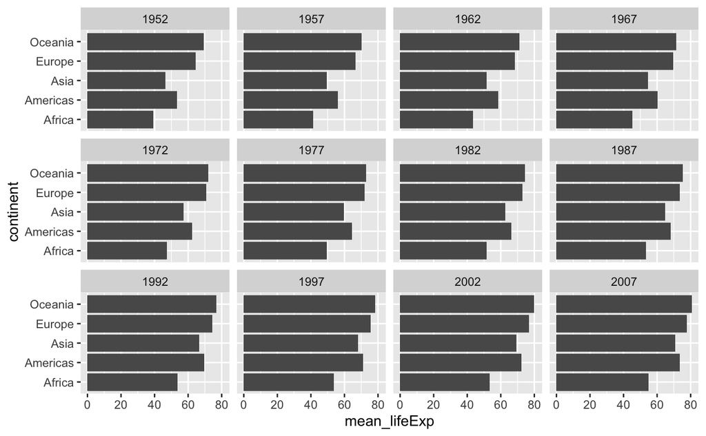

```r
gapminder %>% group_by(year,continent) %>% summarise(mean_lifeExp=mean(lifeExp)) %>%
  ggplot() + geom_bar(aes(x=continent,y=mean_lifeExp),stat="identity") +
  facet_wrap(~year) + coord_flip()
```

The other is to rotate the labels:

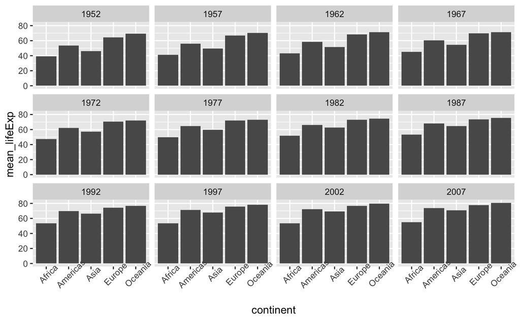

```r
gapminder %>% group_by(year,continent) %>% summarise(mean_lifeExp=mean(lifeExp)) %>%
  ggplot() + geom_bar(aes(x=continent,y=mean_lifeExp),stat="identity") +
  facet_wrap(~year) + theme(axis.text.x = element_text(angle = 45))
```

**Exercise** What information might be determined from this plot?

Another way to look at this same information is for example with

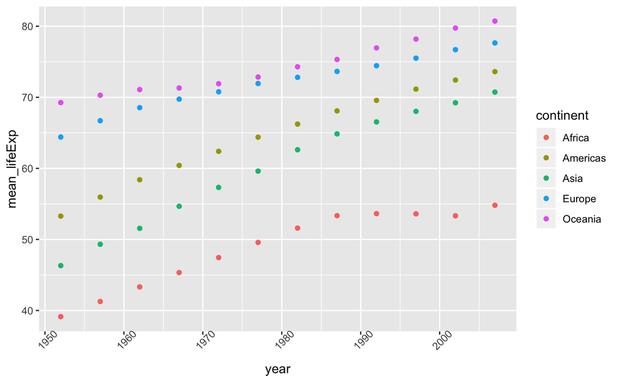

```r
gapminder %>% group_by(year,continent) %>% summarise(mean_lifeExp=mean(lifeExp)) %>%
  ggplot() + geom_point(aes(x=year,y=mean_lifeExp,color=continent)) +
  theme(axis.text.x = element_text(angle = 45))
```

**Exercise** What information might be determined from this plot? Comparing this plot with the previous, which is more effetive?

For our next topic, [exploratory data analysis](https://en.wikipedia.org/wiki/Exploratory_data_analysis) (EDA) we will see how wrangling and visualization can be put together in order to determine some relevant data-driven questions and to take steps toward beginning the modeling process.